# Stat Rethinking 2 - Chatper 14.2

Now looking at more than two varying effects. Varying intercepts and more than one slope.

```r
library(rethinking)
data("chimpanzees")
d <- chimpanzees

d$block_id <- d$block
d$treatment <- 1L + d$prosoc_left + 2L*d$condition

dat <- list(
  L = d$pulled_left,
  tid = d$treatment,
  actor = d$actor,
  block_id = as.integer(d$block_id)
)
```

```r
set.seed(4387510)

m14.2 <- ulam(
  alist(
    # Likelihood - each chimp as probability p of pulling left per trial
    L ~ dbinom(1, p),

    # Linear model, this probability depends on the treatment, the chimp and the experimental block
    # Each treatment has a fixed effect per itself, and per chimp and block
    # Each chimp also has a fixed effect, as does each block
    logit(p) <- g[tid] + alpha[actor, tid] + beta[block_id, tid],

    # Adaptive priors for actors and blocks. Each prior is learnt from the data with pooling.
    # There is also co-variance between different actors. Learning about one actor can tell us
    # info about the others. Ditto blocks.
    vector[4]:alpha[actor] ~ multi_normal(0, Rho_actor, sigma_actor),
    vector[4]:beta[block_id] ~ multi_normal(0, Rho_block, sigma_block),

    # Fixed priors
    g[tid] ~ dnorm(0, 1),
    sigma_actor ~ dexp(1),
    Rho_actor ~ dlkjcorr(4),
    sigma_block ~ dexp(1),
    Rho_block ~ dlkjcorr(4)
  ), data=dat, chains=4
)
```

Have divergent transitions again, now we need to use a Cholesky factors. Same principle of smuggling out, but trickier.

```r
m14.3 <- ulam(
  alist(
    L ~ binomial(1, p),
    logit(p) <- g[tid] + alpha[actor, tid] + beta[block_id, tid],

    transpars> matrix[actor, 4]:alpha <- compose_noncentered(sigma_actor, L_Rho_actor, z_actor),
    transpars> matrix[block_id, 4]:beta <- compose_noncentered(sigma_block, L_Rho_block, z_block),

    matrix[4, actor]:z_actor ~ normal(0, 1),
    matrix[4, block_id]:z_block ~ normal(0, 1),

    g[tid] ~ normal(0, 1),
    vector[4]:sigma_actor ~ dexp(1),
    vector[4]:sigma_block ~ dexp(1),
    cholesky_factor_corr[4]:L_Rho_actor ~ lkj_corr_cholesky(2),
    cholesky_factor_corr[4]:L_Rho_block ~ lkj_corr_cholesky(2),

    gq> matrix[4,4]:Rho_actor <<- Chol_to_Corr(L_Rho_actor),
    gq> matrix[4,4]:Rho_block <<- Chol_to_Corr(L_Rho_block)

  ), data=dat, chains=4, log_lik = TRUE, iter=4000
)
```

```r
precis(m14.3, depth=2, pars=c("sigma_actor", "sigma_block"))
```

|  | mean | sd | 5.5% | 94.5% | n_eff | Rhat4 |
| --- | --- | --- | --- | --- | --- | --- |
| sigma_actor[1] | 1.39 | 0.49 | 0.78 | 2.25 | 3715 | 1 |
| sigma_actor[2] | 0.90 | 0.39 | 0.41 | 1.59 | 4641 | 1 |
| sigma_actor[3] | 1.84 | 0.56 | 1.12 | 2.84 | 5459 | 1 |
| sigma_actor[4] | 1.58 | 0.59 | 0.85 | 2.66 | 5261 | 1 |
| sigma_block[1] | 0.41 | 0.33 | 0.04 | 1.01 | 4235 | 1 |
| sigma_block[2] | 0.44 | 0.35 | 0.04 | 1.08 | 4136 | 1 |
| sigma_block[3] | 0.30 | 0.27 | 0.02 | 0.80 | 7003 | 1 |
| sigma_block[4] | 0.48 | 0.38 | 0.04 | 1.15 | 3681 | 1 |

Only the means of the posterior, the actual shrinkage isn’t always the mean here, but is averaged over the entire posterior distribution.

However, can see that the values in sigma_block are very small. This means not much variation between the various treatments in different blocks, everything gets shrunk if a block *is* different.

```r
# compute mean for each actor in each treatment
pl <- by( d$pulled_left , list( d$actor , d$treatment ) , mean )
# generate posterior predictions using link
datp <- list(
actor=rep(1:7,each=4) ,
tid=rep(1:4,times=7) ,
block_id=rep(5,times=4*7) )
p_post <- link( m14.3 , data=datp )
p_mu <- apply( p_post , 2 , mean )
p_ci <- apply( p_post , 2 , PI )
# set up plot
plot( NULL , xlim=c(1,28) , ylim=c(0,1) , xlab="" ,
ylab="proportion left lever" , xaxt="n" , yaxt="n" )
axis( 2 , at=c(0,0.5,1) , labels=c(0,0.5,1) )
```

```r
abline( h=0.5 , lty=2 )
for ( j in 1:7 ) abline( v=(j-1)*4+4.5 , lwd=0.5 )
```

```r
for ( j in 1:7 ) text( (j-1)*4+2.5 , 1.1 , concat("actor ",j) , xpd=TRUE )
xo <- 0.1 # offset distance to stagger raw data and predictions
# raw data
for ( j in (1:7)[-2] ) {
lines( (j-1)*4+c(1,3)-xo , pl[j,c(1,3)] , lwd=2 , col=rangi2 )
lines( (j-1)*4+c(2,4)-xo , pl[j,c(2,4)] , lwd=2 , col=rangi2 )
}
```

```r
points( 1:28-xo , t(pl) , pch=16 , col="white" , cex=1.7 )
points( 1:28-xo , t(pl) , pch=c(1,1,16,16) , col=rangi2 , lwd=2 )
```

```r
yoff <- 0.175
text( 1-xo , pl[1,1]-yoff , "R/N" , pos=1 , cex=0.8 )
text( 2-xo , pl[1,2]+yoff , "L/N" , pos=3 , cex=0.8 )
```

```r
text( 3-xo , pl[1,3]-yoff , "R/P" , pos=1 , cex=0.8 )
text( 4-xo , pl[1,4]+yoff , "L/P" , pos=3 , cex=0.8 )
```

```r
# posterior predictions
for ( j in (1:7)[-2] ) {
lines( (j-1)*4+c(1,3)+xo , p_mu[(j-1)*4+c(1,3)] , lwd=2 )
lines( (j-1)*4+c(2,4)+xo , p_mu[(j-1)*4+c(2,4)] , lwd=2 )
}
for ( i in 1:28 ) lines( c(i,i)+xo , p_ci[,i] , lwd=1 )
```

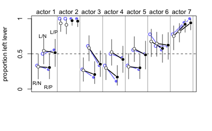

```r
points( 1:28+xo , p_mu , pch=16 , col="white" , cex=1.3 )
points( 1:28+xo , p_mu , pch=c(1,1,16,16) )
```

Blue - Raw Data Black - Model posterior predictions Open - No Partner Filled - Partner Lines are 89% compatability intervals

Can see far more variation among individuals then earlier models.

The posterior predictions aren’t just a repeat of the data. This is good!

Leftie (actor 2) always pulls the left lever. Here leftie is shrunk to have some chance of pulling right. Shrinks more in treatments 1 and 2 (i.e. those without a partner present) because there was less variation amongst all actors for these treatments. This is what we see with the four sigma_actor values above. The smaller sigma actor means more shrinkage to the mean. More suprised by large values here.

Same interpretation - treatment doesn’t have any effect.

Advantage in this model is we can see individual responses. E.g. maybe some people *do* respond to aspirin, even if at a population level this doesn’t have an effect.